# Proyecto

César Alcívar

3/1/2022

```r
if(!require("tidyverse")) install.packages("tidyverse")
library(tidyverse)
```

# 1 Elección del conjunto de datos

El dataset [Marketing Campaign](https://www.kaggle.com/rodsaldanha/arketing-campaign) contiene información de clientes que han aceptado o no ofertas de productos o servicios de una tienda. El objetivo de este trabajo es predecir que clientes responderán a una oferta de un producto o servicio.

# 2 Exploración del conjunto de datos

Cargamos el dataset en la variable `df`.

```r
df = read.csv('../data/marketing_campaign.csv', sep = ";", stringsAsFactors = T)
dim(df)
```

```
## [1] 2240   29
```

Se observa que el dataset tiene 2240 registros y 29 columnas. A continuación, se describen los campos del dataset:

- ID: el código de identificación único para cada cliente.
- Year_Birth: el año de nacimiento de un cliente.
- Education: el nivel de educación que completó un cliente.
- Marital_Status: Estado del matrimonio.
- Income: Ingresos anuales.
- Kidhome: número de niños menores de 13 años en el hogar del cliente.
- Teenhome: número de niños entre 13 y 19 años en el hogar del cliente.
- Dt_Customer: fecha de inscripción del cliente.
- Recency: # de días desde la última compra.
- MntWines: cantidad en dólares de vinos comprados en los últimos 2 años
- MntFruits: cantidad en dólares de frutas compradas en los últimos 2 años
- MntMeatProducts: cantidad en dólares de productos cárnicos comprados en los últimos 2 años.
- MntFishProducts: cantidad en dólares de productos pesqueros comprados en los últimos 2 años.
- MntSweetProducts: Cantidad en dólares de productos dulces comprados en los últimos 2 años.
- MntGoldProds: cantidad en dólares de productos Gold comprados en los últimos 2 años.
- NumDealsPurchases: # de compras realizadas con descuento.
- NumWebPurchases: # de compras realizadas a través del sitio web de la empresa.
- NumCatalogPurchases: # de compras realizadas usando el catálogo.
- NumStorePurchases: # de compras realizadas directamente en la tienda
- NumWebVisitsMonth: # de visitas realizadas a través del sitio web de la empresa.
- AcceptedCmp1: 1 si el cliente aceptó la oferta en la primera campaña, 0 en caso contrario.
- AcceptedCmp2: 1 si el cliente aceptó la oferta en la segunda campaña, 0 en caso contrario
- AcceptedCmp3: 1 si el cliente aceptó la oferta en la tercera campaña, 0 en caso contrario.
- AcceptedCmp4: 1 si el cliente aceptó la oferta en la cuarta campaña, 0 en caso contrario.
- AcceptedCmp5: 1 si el cliente aceptó la oferta en la quinta campaña, 0 en caso contrario.
- Complain: 1 si el cliente se quejó en los últimos 2 años, 0 en caso contrario.
- Response: 1 si el cliente aceptó la oferta en la última campaña, 0 en caso contrario.

# 3 Preprocesamiento y limpieza de datos

Se convierten los campos de tipo entero a tipos numéricos, y el campo “Dt_Customer” se convierte a “Date.”

```r
# Se seleccionan los columnas 1,3,4,8 del dataset
name.cols = names(df[, -c(1,3,4,8)])

# Se cambian las columnas 1, 3, 4, 8 de tipo entero a númerico
df <- df %>%
  mutate_at(name.cols, as.numeric) %>%
  mutate(Dt_Customer = as.Date(Dt_Customer))
```

Se verifican los valores del campo “Marital_Status.”

```r
summary(df$Marital_Status)
```

```
##   Absurd    Alone Divorced  Married   Single Together    Widow     YOLO
##        2        3      232      864      480      580       77        2
```

El campo “Marital_Status” tienen 8 niveles diferentes. Algunos niveles se pueden combinar (“Alone” y “Single”), otros no. No se conocen los estados civiles “Absurd” y “Yolo” por lo que se los eliminará del dataset. Se van a clasificar los estados “Alone,” “Diverced,” “Widow” y “Single” en un solo estado “Single.” Los estados “Married” y “Together” se va a clasificar como “Coupled.”

```r
# Se cambia "Alone", "Divorced", "Widow", "Single" por "Single"
df$Rel_Status[df$Marital_Status %in% c("Alone", "Divorced", "Widow", "Single")] <- "Single"
# Se cambia "Married", "Together" por "Coupled"
df$Rel_Status[df$Marital_Status %in% c("Married", "Together")] <- "Coupled"
# Se cambia "Absurd", "YOLO" por ""
df$Rel_Status[df$Marital_Status %in% c("Absurd", "YOLO")] <- ""
# Se eliminan los estados "Absurd", "YOLO"
df <- df %>% filter(Rel_Status != "")
summary(as.factor(df$Rel_Status))
```

```
## Coupled  Single
##    1444     792
```

Empezamos a inspeccionar las variable númericas. Comenzaremos por “Income.”

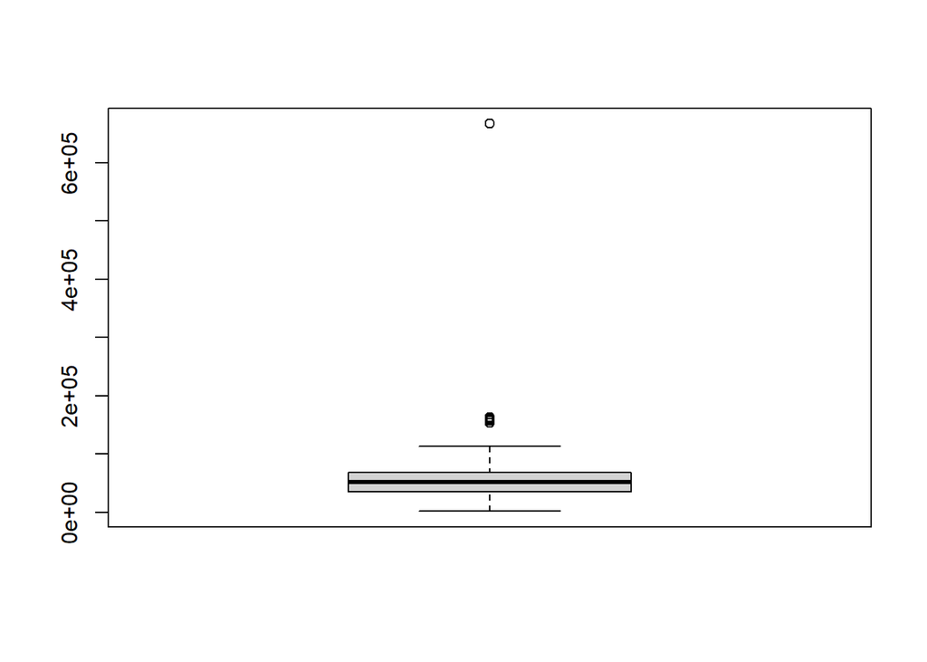

```r
boxplot(df$Income)
```

En el gráfico se observa que la mayoría de los datos están por debajo de los 200k. Se observan outliers que tiene un salario mayor a 600k. Podría tratarse de un error de un error o cierto cliente millonario. No parece que ayude a el análisis, por lo que será útil deshacerse de él.

```r
# Se seleccionan los datos externos de Income
ouliers <- boxplot(df$Income, plot = FALSE)$out
# Se eliminan los ouliers
df <- df %>% filter(Income < max(ouliers) - 1)
```

A continuación, se calcula la edad del cliente y se suman la cantidad de hijos.

```r
df <- df %>%
  mutate(MntSpent = MntFishProducts + MntMeatProducts + MntFruits + MntSweetProducts + MntWines + MntGoldProds) %>%
  mutate(NumPurchases = NumCatalogPurchases + NumStorePurchases + NumWebPurchases) %>%
  mutate(MinorsHome = Kidhome + Teenhome)  %>%
  mutate(AcceptedPrv = AcceptedCmp1 + AcceptedCmp2 + AcceptedCmp3 + AcceptedCmp4 + AcceptedCmp5) %>%
  mutate(Age = as.numeric(format(Dt_Customer, format = '%Y')) - Year_Birth)


df <- df  %>%
    #Se ordenan las columnas alfabeticamente
  select(sort(colnames(df))) %>%
    # Se borran columnas innecesarias
  select(-one_of(c('ï..ID', 'Kidhome', 'Marital_Status', 'Teenhome', 'Year_Birth', 'Z_CostContact', 'Z_Revenue'))) %>%
    # Se borran datos en blanco y NA
  mutate_all(na_if, '') %>% na.omit()

head(df)
```

```
##   AcceptedCmp1 AcceptedCmp2 AcceptedCmp3 AcceptedCmp4 AcceptedCmp5 AcceptedPrv
## 1            0            0            0            0            0           0
## 2            0            0            0            0            0           0
## 3            0            0            0            0            0           0
## 4            0            0            0            0            0           0
## 5            0            0            0            0            0           0
## 6            0            0            0            0            0           0
##   Age Complain Dt_Customer  Education Income MinorsHome MntFishProducts
## 1  55        0  2012-09-04 Graduation  58138          0             172
## 2  60        0  2014-03-08 Graduation  46344          2               2
## 3  48        0  2013-08-21 Graduation  71613          0             111
## 4  30        0  2014-02-10 Graduation  26646          1              10
## 5  33        0  2014-01-19        PhD  58293          1              46
## 6  46        0  2013-09-09     Master  62513          1               0
##   MntFruits MntGoldProds MntMeatProducts MntSpent MntSweetProducts MntWines
```

[output cut: 20 more lines]

```r
df$Response <- ifelse(df$Response == 1, "Accepted", "Not accepted")
```

Verificamos la edad de los cliente.

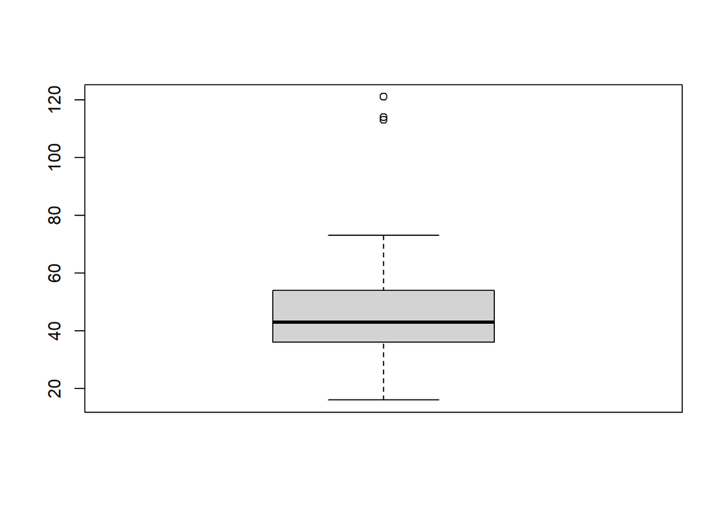

```r
boxplot(df$Age)
```

Se observan edades arriba de los 100 años. Esto seguramente se debe a algún error en el dataset, por lo que se eliminarán a continuación.

```r
outliers <- boxplot(df$Age, plot = FALSE)$out
df <- df %>%
    filter(Age < min(outliers))
```

## 3.1 Nuevas variables

# 4 Multiple factor analysis (MFA)

Para el análisis y la obtención de los Componentes Principales, se utilizó el libro Kassambara (2017). Multiple Factor Analysis (MFA) es un método de análisis de datos multivariado para resumir y visualizar un dataset en la que los campos se describen mediante varios conjuntos de variables (cuantitativos y/o cualitativos) estructurados en grupos. MFA está basado en:

- Principal component analysis cuando las variables con cuantitativas,
- Multiple correspndence analysis cuando las variables con cualitativas.

MFA equilibra la influencia de cada grupo de variables. Las variables de un mismo grupo se normalizan utilizando el mismo valor de ponderación, que puede variar de un grupo a otro. A continuación, se describen las agrupaciones que se realizarán en el análisis MFA:

- Grupo 1 (education_maritalstatus): “Education,” “Rel_Status” grupo de variables categóricas.
- Grupo 2 (age_minorsHome): “Age” y MinorsHome grupo de variables numéricas escalares.
- Grupo 3 (Income): “Income” grupo de variable numérica continua.
- Grupo 4 (accepted): “AcceptedPrv” grupo de variable numérica escalar.
- Grupo 5 (numpurchase): “NumPurchases” grupo de variable numérica escalar.
- Grupo 6 (mntspent): “MntSpent” grupo de variable numéricas continua.
- Grupo 7 (complian): “Complain” grupo de variable numérica escalar.

En este trabajo se utilizarán los siguientes paquetes:

- Paquete “FactorMineR” para calcular los componentes principales.
- y el paquete “factorextra” para extraer, visualizar e interpretar los resultados.

```r
if(!require("FactoMineR")) install.packages("FactoMineR")
library(FactoMineR)

if(!require("factoextra")) install.packages("factoextra")
library(factoextra)
```

Se separan las campos antes mencionados en otro dataframe.

```r
df.mfa <- data.frame(Education=df$Education, Rel_Status=df$Rel_Status, Age=df$Age, MinorsHome=df$MinorsHome, Income=df$Income, AcceptedPrv=df$AcceptedPrv, NumPurchases=df$NumPurchases, MntSpent=df$MntSpent, Complain=df$Complain)
head(df.mfa)
```

```
##    Education Rel_Status Age MinorsHome Income AcceptedPrv NumPurchases MntSpent
## 1 Graduation     Single  55          0  58138           0           22     1617
## 2 Graduation     Single  60          2  46344           0            4       27
## 3 Graduation    Coupled  48          0  71613           0           20      776
## 4 Graduation    Coupled  30          1  26646           0            6       53
## 5        PhD    Coupled  33          1  58293           0           14      422
## 6     Master    Coupled  46          1  62513           0           20      716
##   Complain
## 1        0
## 2        0
## 3        0
## 4        0
## 5        0
## 6        0
```

A continuación, se establecen las variables en grupos de componentes principales:

```r
res.mfa <- MFA(df.mfa, group = c(2, 2, 1, 1, 1, 1, 1), type = c("n", "s", "c", "s", "c", "s", "s"), name.group = c("education_maritalstatus", "age_minorsHome", "Income", "accepted", "mntspent", "numpurchase", "complian"), graph = FALSE, num.group.sup = c(1, 7))
```

En la función `MFA`, el atributo `group` se especificó el número de variables que pertenecen al grupo. En el atributo `type` se especificó el tipo de variables de cada grupo, “n” para datos categóricos, “s” para números escalares y “c” para números continuos. En la variable `res.mfa` se guardan los resultados de la disminución de la dimensionalidad del dataset original en componentes principales o dimensiones.

## 4.1 Visualización e Interpretación

### 4.1.1 Varianza Explicada

A continuación, se explica la proporción de varianza en los componentes principales creados.

```r
eig.val <- get_eigenvalue(res.mfa)
head(eig.val)
```

```
##       eigenvalue variance.percent cumulative.variance.percent
## Dim.1  3.0701312        52.675020                    52.67502
## Dim.2  1.0166070        17.442184                    70.11720
## Dim.3  0.7638682        13.105880                    83.22308
## Dim.4  0.5842105        10.023449                    93.24653
## Dim.5  0.2543639         4.364186                    97.61072
## Dim.6  0.1392578         2.389282                   100.00000
```

La proporción de varianza explicada por cada dimensión la encontramos en la segunda columna. El porcentaje acumulado está en la tercera columna. Para este caso, los primeros tres componentes principales (Dims.) explican el 83% de la varianza del dataset.

A coninuación, se muestra una gráfica de los varianza explicada.

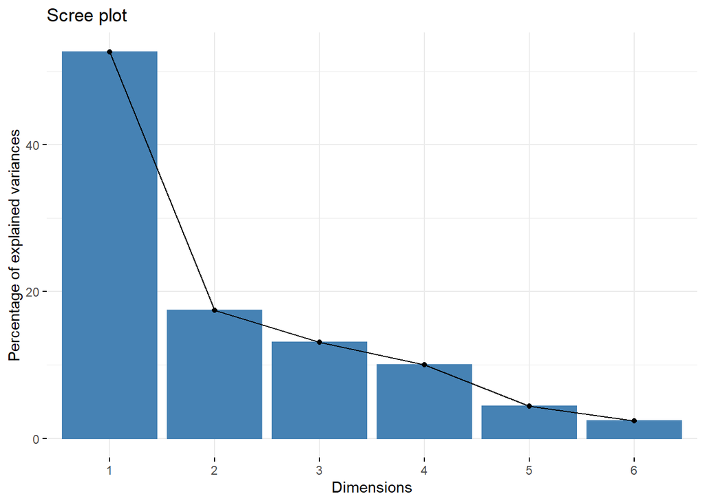

```r
fviz_screeplot(res.mfa)
```

## Contribución de las variables en los Componentes Principales

Para graficar cuanto contribuyen los grupos de variables a las dimensiones, utilizaremos la función `fviz_contrib()`:

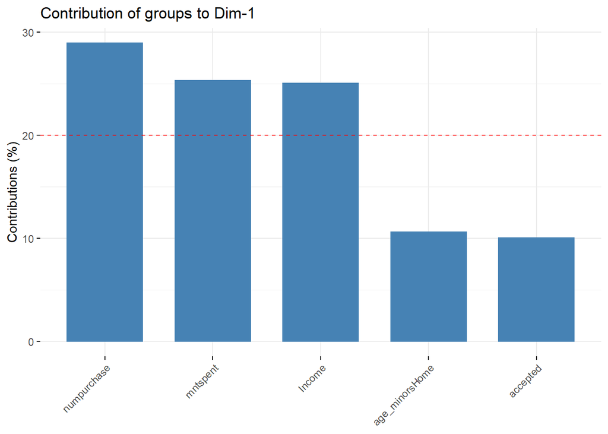

```r
# Contribución en Dim1
fviz_contrib(res.mfa, "group", axes = 1)
```

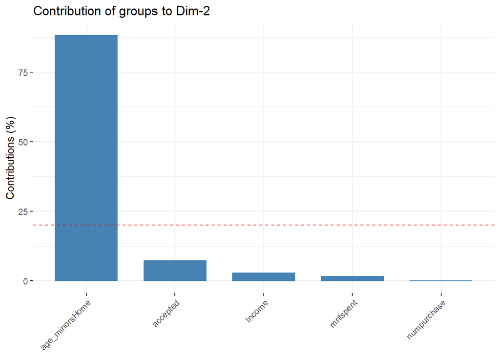

```r
# Contribución en Dim2
fviz_contrib(res.mfa, "group", axes = 2)
```

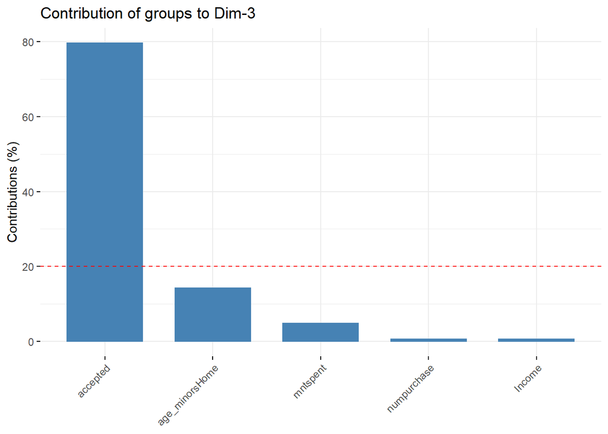

```r
# Contribución en Dim3
fviz_contrib(res.mfa, "group", axes = 3)
```

La línea punteada roja en el gráfico anterior indica la contribución esperada del grupo de variables en las Dims o componentes principales. Si la medida de un grupo de variables esta por arriba de la línea se considera que su contribución es importante para el componente. Para este caso, el grupo de variables que más contribuyen a Dim1 son “numpurchase,” “mntspent” e “Income.” Para Dim2 el grupo de variables que más contribuye es “age_minorsHome.” Para Dim3 es el grupo “accepted.”

## 4.2 Principal Component Dataset

A continuación, se crea un dataframe con los tres primeros PC y con la variable clasificadora “Response.” Este dataset, será utilizado en las siguientes ejercicios.

```r
df.principal_components <- data.frame(PC1 = res.mfa$ind$coord[,1], PC2 = res.mfa$ind$coord[,2], PC3 = res.mfa$ind$coord[,3], Response=df$Response)
head(df.principal_components)
```

```
##          PC1        PC2        PC3     Response
## 1  2.0280210  0.5271225 -1.1071551     Accepted
## 2 -1.6773007  1.5963871  0.6338437 Not accepted
## 3  1.3956030  0.1488762 -1.0736251 Not accepted
## 4 -1.8115895 -1.1116989 -0.1912311 Not accepted
## 5 -0.1641634 -0.5313647 -0.5571336 Not accepted
## 6  0.7175826  0.4861116 -0.6242092 Not accepted
```

## 4.3 Conclusiones

- El grupo de variables que más contribuyen a Dim1 son “numpurchase,” “mntspent” e “Income.” Para Dim2 el grupo de variables que más contribuye es “age_minorsHome.” Para Dim3 es el grupo “accepted”
- El grupo “numpurchase” es compuesto por la variable “NumPurchases.” El grupo “mntspent” está compuesta por la variable “MntSpent.” El grupo “Income” está compuesta por la variable “Income.” El grupo “age_minorsHome” está compuesta por las variables “Age” y “MinorsHome.” El grupo “accepted” está compuesta por la variable “AcceptedPrv”
- Los componentes PC1 y PC2 explican el 70% de la variabilidad del dataset y con la suma del componente PC3 explicarían el 83%.

# 5 Ejercicio 1

En este ejercicio se utilizará el dataset de componentes principales con el algoritmo K-means para crear clústers, y luego verificar que tan cerca están los clústeres de la clasificación real.

## 5.1 Análisis visual utilizando Componentes Principales

Los dos primeros componentes principales representan el 70% de la variabilidad de los datos y son los que vamos a utilizar para evaluar el algoritmo K-means. A continuación, se realizará un análisis visual de los dos primeros componentes, mostrando como están distribuidos los registros por la variable `Response`.

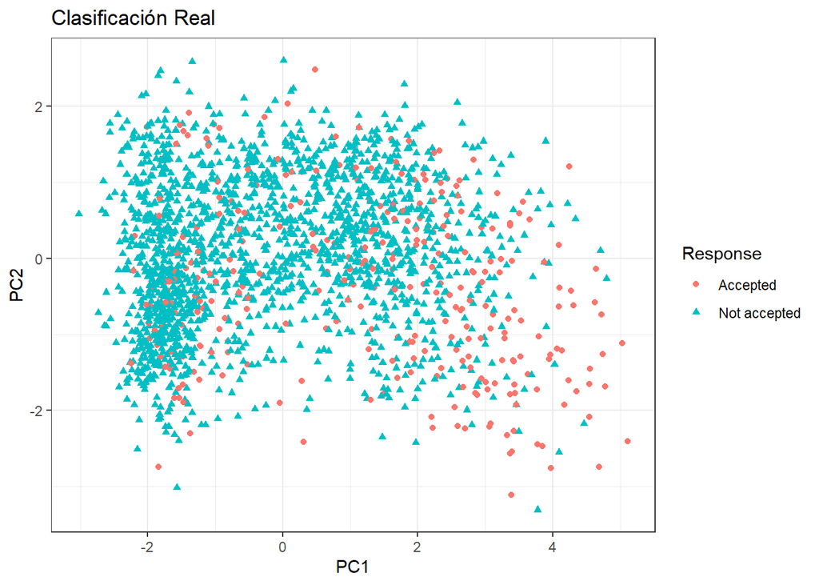

```r
ggplot(df.principal_components, aes(PC1, PC2, shape = Response, color=Response)) +
  ggtitle("Clasificación Real") +
  geom_point()  +
  theme_bw()
```

En la gráfica se observa que no existe una separación entre los clientes de aceptaron la oferta y los que no aceptaron la oferta en la última campaña de marketing.

## 5.2 Algoritmo Kmeans

K-means es un algoritmo de clasificación no supervisado que consiste en dividir los datos en diferentes grupos, donde los registros de cada grupo son similares entre sí. Para establecer las agrupaciones se mínimiza la suma de las distancias con la media de su grupo.

Existen diferentes métodos para calcular la distancia en K-means. Para nuestro estudio, utilizaremos la distancia euclidiana. A continuación, se detalla la fórmula:

$$distancia = \sqrt{(x_1 - u_1)^2 + (x_2 - u_1)^2 + \cdots + (x_p - u_p)^2}$$

## 5.3 Coeficiente de silhouette

El coeficiente de silhouette proporciona un valor entre -1.0 y 1.0, he indica lo bien o mal que se está agrupando un punto en su clúster. Los valores cercanos a 1.0 indican que el punto está en el grupo correcto. Los valores cercanos a -1.0 indican que el punto está en el grupo incorrecto.

Para calcular el coeficiente de silhouette se utiliza la función `silhouette` del paquete `cluster`.

```r
if(require("cluster")) install.packages("cluster")
library(cluster)
```

A continuación, se calcular el coeficiente silhouette.

```r
# se crea la matriz de distancias por pares entre los elementos del dataset.
d   <- daisy(df.principal_components[, 1:2])
SC  <- c(0,10)

for(k in c(2,3,4,5,6,7,8,9,10)){
  fit       <- kmeans(df.principal_components[, 1:2], k)
  y_cluster <- fit$cluster # se obtienen los clusters
  sk        <- silhouette(y_cluster, d) # se calcula el S(X_i)
  SC[k]     <- mean(sk[,3]) # se calcula el coeficiente de silhouette
}
```

Se muestra en la gráfica los valores de las siluetas de cada prueba para comprobar que número de clúster es el mejor.

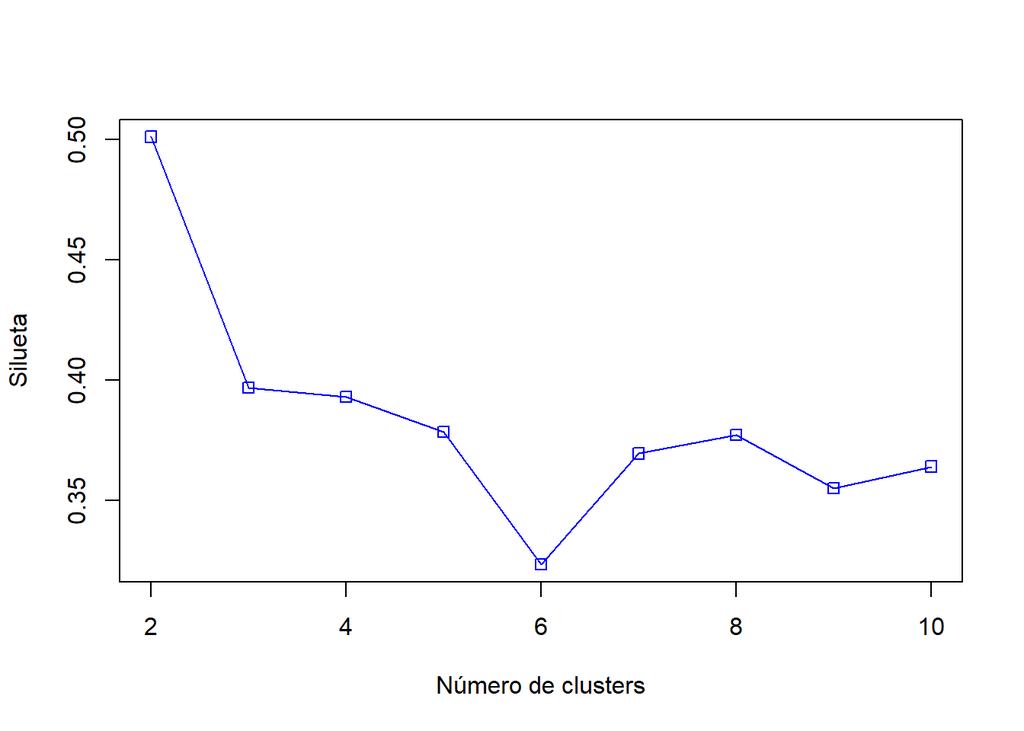

```r
plot(2:10, SC[2:10], type='o', pch=0, col='blue', xlab = "Número de clusters", ylab = "Silueta")
```

## 5.4 Método elbow (codo)

El método del codo consiste en iterar el mismo conjunto de datos para distintos valores del número de clústers, y por inspección gráfica se seleccionará el valor que se encuentra en el “codo” de la curva.

A continuación, se calcula el método del codo:

```r
SSW   <- rep(0, 10)
for(k in c(2,3,4,5,6,7,8,9,10)){
  set.seed(123)
  fit         <- kmeans(df.principal_components[, 1:2], k)
  SSW[k]      <- fit$tot.withinss
}
```

Se muestra en la gráfica los valores de las distancias de cada prueba para comprobar que número de clúster es el mejor.

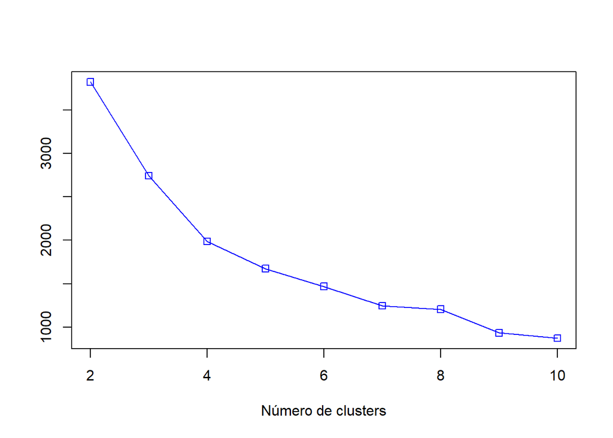

```r
plot(2:10, SSW[2:10], type = 'o', col='blue', pch=0, ,xlab="Número de clusters", ylab="")
```

En este caso el número óptimo de clústers son 4, que es cuando la curva comienza a estabilizarse.

## 5.5 Método Calinski-Harabasz

```r
if (!require('fpc')) install.packages('fpc')
library(fpc)

fit_ch  <- kmeansruns(df.principal_components[, 1:2], krange = 1:10, criterion = "ch")
fit_ch$bestk
```

```
## [1] 2
```

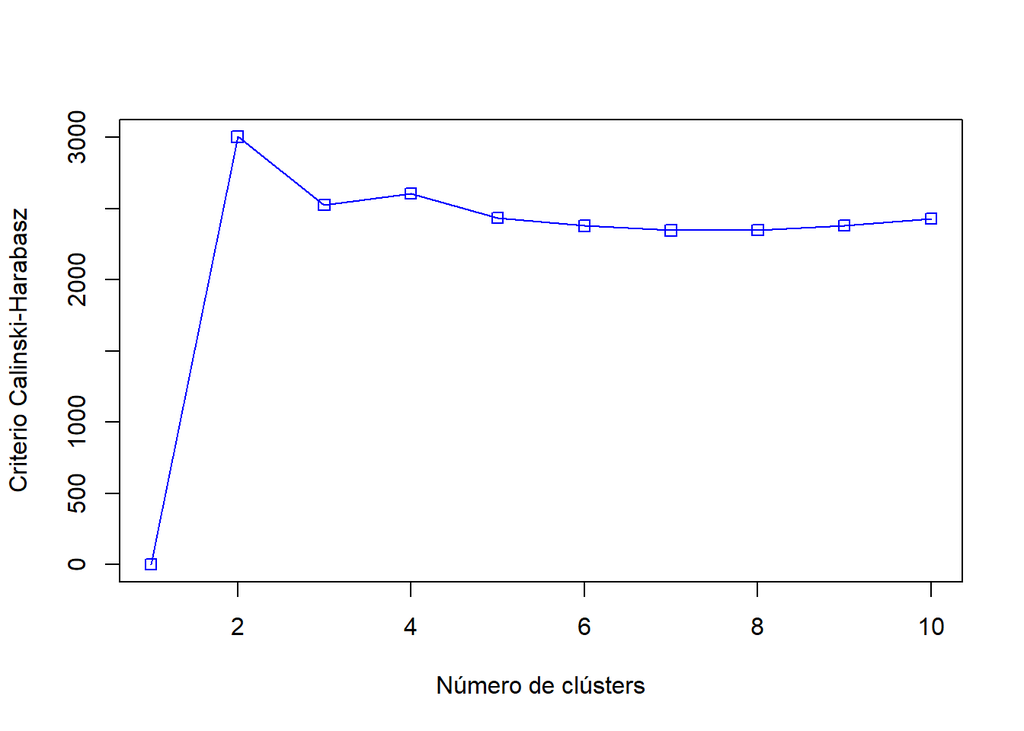

```r
plot(1:10,fit_ch$crit,type="o",col="blue",pch=0,xlab="Número de clústers",ylab="Criterio Calinski-Harabasz")
```

Los resultados son muy parecidos a los que hemos obtenido anteriormente. Con el criterio con el Calinski-Harabasz se obtienen 2.

## 5.6 Comparación visual de los k-óptimos

A continuación, se prueba el modelo con diferentes valores de `k`.

```r
set.seed(123)

k <- 2
fit2 <- kmeans(df.principal_components[, 1:2], k)
df.principal_components$cluster2 <- as.factor(fit2$cluster)

k <- 3
fit3 <- kmeans(df.principal_components[, 1:2], k)
df.principal_components$cluster3 <- as.factor(fit3$cluster)

k <- 4
fit4 <- kmeans(df.principal_components[, 1:2], k)
df.principal_components$cluster4 <- as.factor(fit4$cluster)
```

Se muestran las gráficas con los clústers calculados.

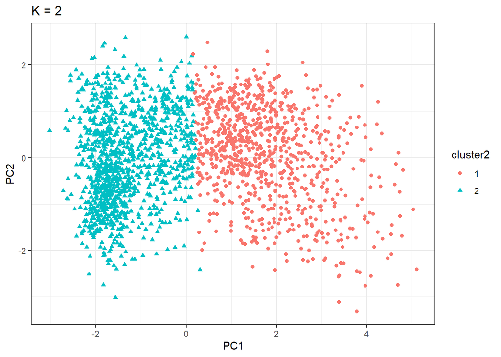

```r
ggplot(df.principal_components, aes(PC1, PC2, shape = cluster2, color=cluster2)) +
  ggtitle("K = 2") +
  geom_point()  +
  theme_bw()
```

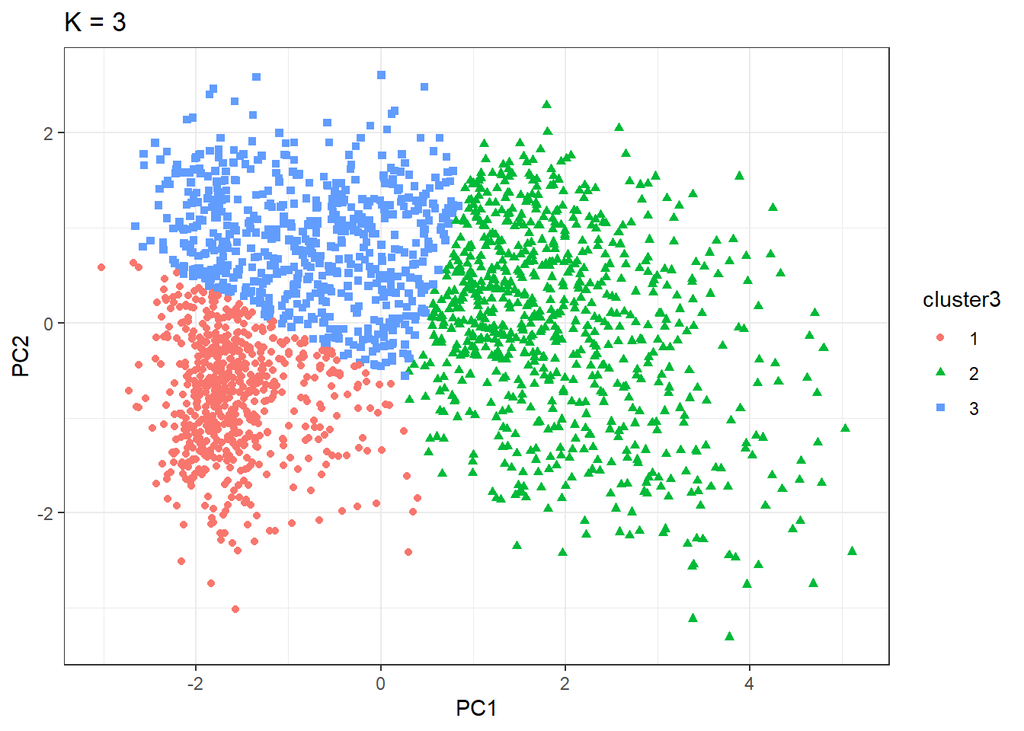

```r
ggplot(df.principal_components, aes(PC1, PC2, shape = cluster3, color=cluster3)) +
  ggtitle("K = 3") +
  geom_point()  +
  theme_bw()
```

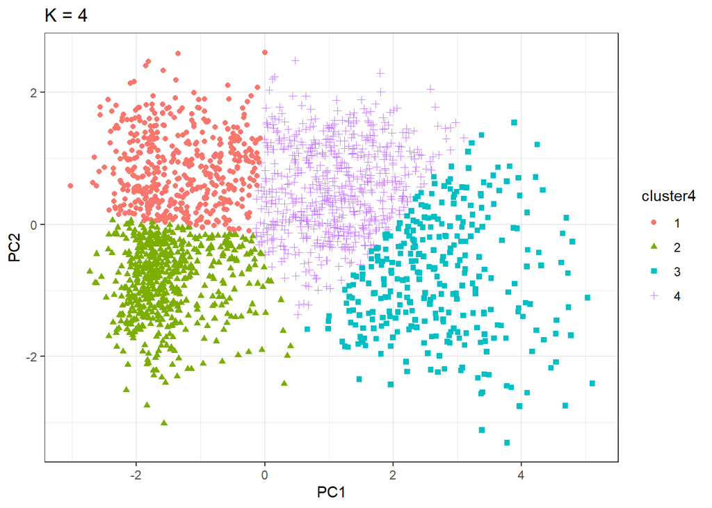

```r
ggplot(df.principal_components, aes(PC1, PC2, shape = cluster4, color=cluster4)) +
  ggtitle("K = 4") +
  geom_point()  +
  theme_bw()
```

Como se observa en las gráficas, ninguna agrupación es buena para describir el etiquetado real de los datos. Los datos no siguen un patrón de agrupación, más bien, se encuentran superpuestos lo que dificulta su clasificación. Por lo que, K-means al formar clústers circulares no sería una buena opción para clasificar registros en este dataset.

# 6 Ejercicio 2

Igual que en el ejercicio 1, en esta sección se va a utiliza K-means para crear clústers, pero con la diferencia de que se va a aplicar la métrica de distancia “Manhattan.”

La distancia de Manhattan es la distancia entre dos puntos atravesados en una sola dirección a la vez (por ejemplo, viajando a lo largo de cuadras rectangulares de la ciudad). A continuación se muestra la fórmula:

$$distancia = |x_1 - u_1| + |x_2 - u_2| + ...+ |x_p + u_p|$$

## 6.1 Coeficiente de silhouette

Para establecer la métrica de distancia “Manhattan” utilizaremos el paquete `cluster` y se establecerá la métrica de distancia en la función `daisy`.

```r
# Se establece la métrica manhattan
d   <- daisy(df.principal_components[,1:2], metric = "manhattan")
SC  <- c(0,10)

for(k in c(2,3,4,5,6,7,8,9,10)){
  set.seed(123)
  fit       <- kmeans(df.principal_components[,1:2], k)
  y_cluster <- fit$cluster # se obtienen los clusters
  sk        <- silhouette(y_cluster, d) # se calcula el S(X_i)
  SC[k]     <- mean(sk[,3]) # se calcula el coeficiente de silhouette
}
```

Se muestra en la gráfica los valores de las siluetas de cada prueba para comprobar que número de clúster es el mejor.

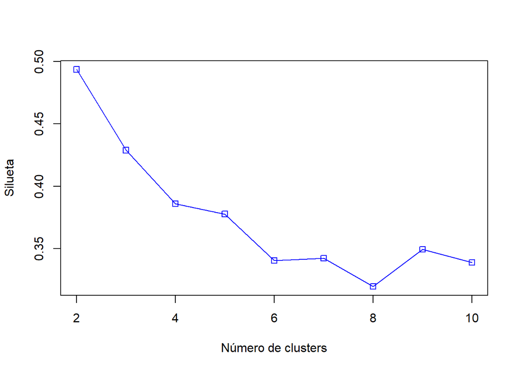

```r
plot(2:10, SC[2:10], type='o', pch=0, col='blue', xlab = "Número de clusters", ylab = "Silueta")
```

## 6.2 Método elbow (codo)

A continuación, se calcula el método del codo:

```r
SSW   <- rep(0, 10)
for(k in c(2,3,4,5,6,7,8,9,10)){
  set.seed(123)
  fit         <- kmeans(d, k) # la variable d contiene las distancias calculadas a través de manhattan
  SSW[k]      <- sum(fit$withinss)
}
```

Se muestra en la gráfica los valores de las distancias de cada prueba para comprobar que número de clúster es el mejor.

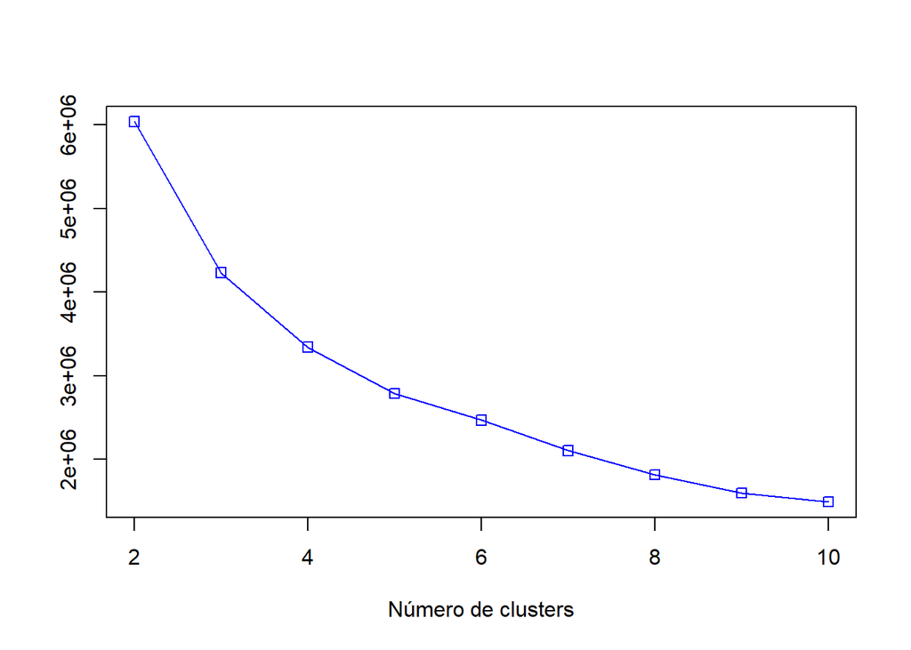

```r
plot(2:10, SSW[2:10], type = 'o', col='blue', pch=0, ,xlab="Número de clusters", ylab="")
```

En este caso el número óptimo de clústers son 4, que es cuando la curva comienza a estabilizarse.

## 6.3 Comparación visual de los k-óptimos

A continuación, se prueba el modelo con diferentes valores de `k`.

```r
set.seed(123)

k <- 2
fit2 <- kmeans(d, k)
df.principal_components$cluster22 <- as.factor(fit2$cluster)

k <- 3
fit3 <- kmeans(d, k)
df.principal_components$cluster32 <- as.factor(fit3$cluster)

k <- 4
fit4 <- kmeans(d, k)
df.principal_components$cluster42 <- as.factor(fit4$cluster)
```

Se muestran las gráficas con los clústers calculados.

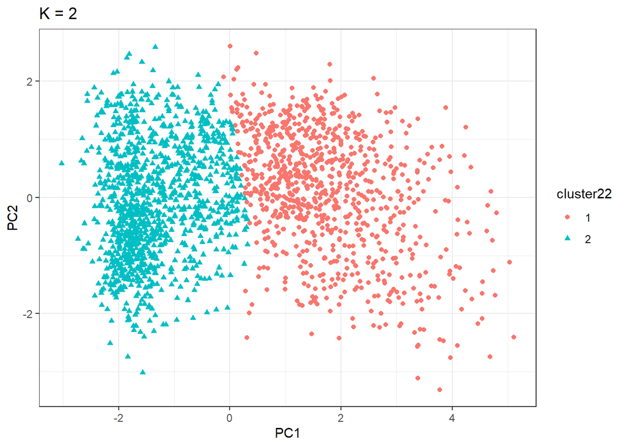

```r
ggplot(df.principal_components, aes(PC1, PC2, shape = cluster22, color=cluster22)) +
  ggtitle("K = 2") +
  geom_point()  +
  theme_bw()
```

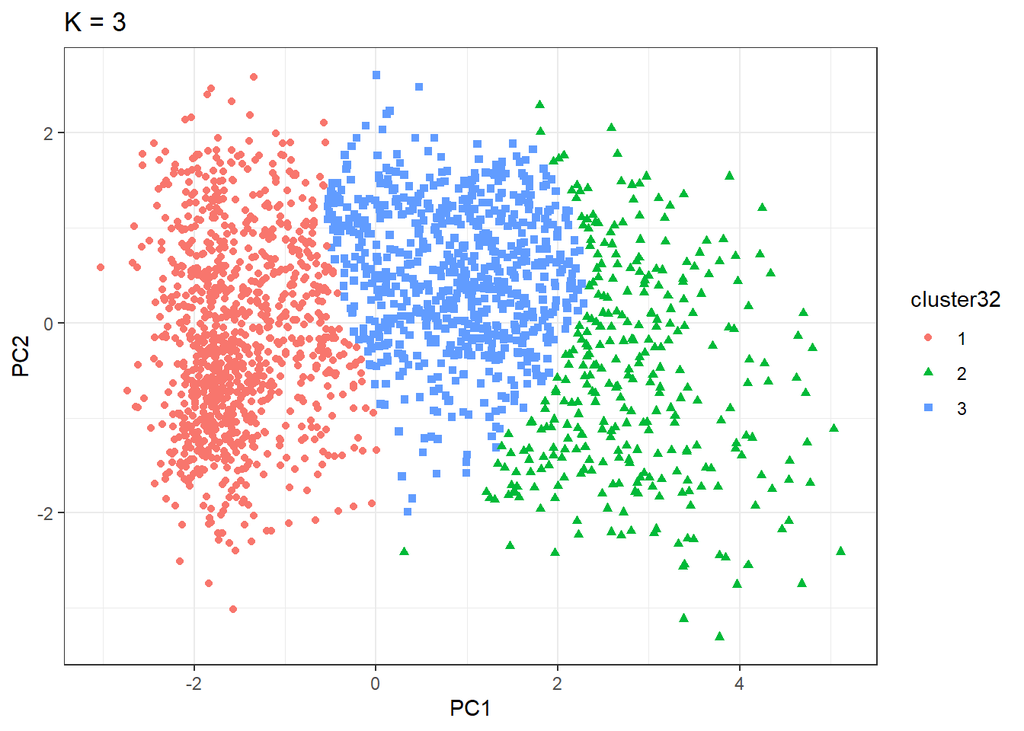

```r
ggplot(df.principal_components, aes(PC1, PC2, shape = cluster32, color=cluster32)) +
  ggtitle("K = 3") +
  geom_point()  +
  theme_bw()
```

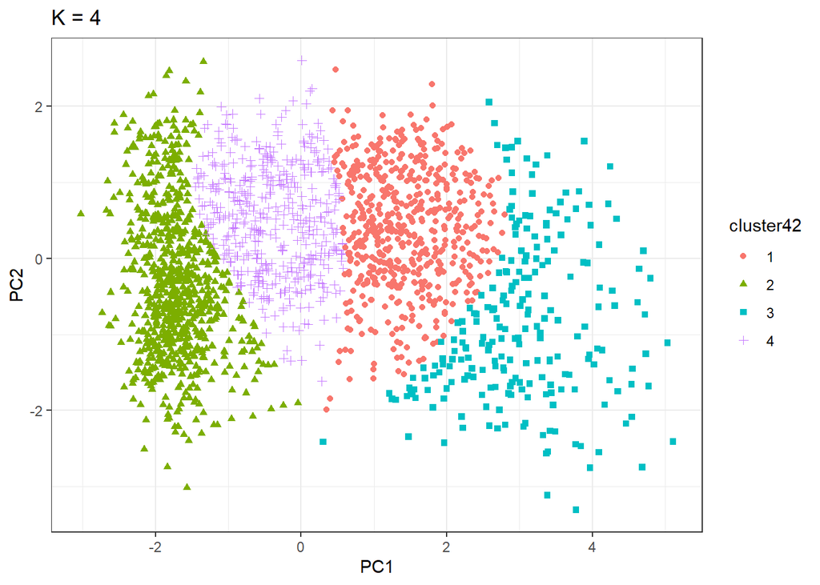

```r
ggplot(df.principal_components, aes(PC1, PC2, shape = cluster42, color=cluster42)) +
  ggtitle("K = 4") +
  geom_point()  +
  theme_bw()
```

# 7 Ejercicio 3

En esta sección se trabajará con los algoritmos DBSCAN y OPTICS. Estos algoritmos definen clústers a través de regiones de alta densidad. Para implementar el algoritmo DBSCAN se requiere dos parámetros:

- El valor épsilon: máximo radio de vecindad.
- El valor minPts: mínimo número de puntos en la épsilon-vecindad de un punto.

Para utilizar el algoritmo DBSCAN, se instala el paquete `dbscan`.

```r
# library(fpc)
if(!require("dbscan")) install.packages("dbscan")
library(dbscan)
```

## 7.1 Probando diferentes valores de eps y minPts

Se define un espacio de búsqueda para los atributos épsilon y minPts para obtener diferentes clústers utilizando la función `expand.grid`. Para épsilon se establece un rango de valores que inicia en 0.3 hasta 0.37 con un incremento de 0.01. Para minPts se estableció el valor de 3.

```r
# Se crea una secuencia de valores de eps y minPts
dbsParamSpace <- expand.grid(eps = seq(0.3, 0.37, 0.01), minPts = 3)
head(dbsParamSpace)
```

```
##    eps minPts
## 1 0.30      3
## 2 0.31      3
## 3 0.32      3
## 4 0.33      3
## 5 0.34      3
## 6 0.35      3
```

Con la función `pmap` del paquete `purrr` se ejecutará el algoritmo DBSCAN con las combinaciones de épsilon y minPts definidos en la variable `dbsParamSpace`.

```r
if(!require("purrr")) install.packages("purrr")
library(purrr)

# Se calcula los clúster con dbscan con los valores de dbsParamSpace
hDbs <- pmap(dbsParamSpace, dbscan, x = df.principal_components[,1:2])
hDbs
```

```
## [[1]]
## DBSCAN clustering for 2208 objects.
## Parameters: eps = 0.3, minPts = 3
## The clustering contains 6 cluster(s) and 26 noise points.
##
##    0    1    2    3    4    5    6
##   26 2150   15    5    4    4    4
##
## Available fields: cluster, eps, minPts
##
## [[2]]
## DBSCAN clustering for 2208 objects.
## Parameters: eps = 0.31, minPts = 3
## The clustering contains 6 cluster(s) and 24 noise points.
##
##    0    1    2    3    4    5    6
##   24 2152   15    5    4    4    4
##
## Available fields: cluster, eps, minPts
##
## [[3]]
## DBSCAN clustering for 2208 objects.
## Parameters: eps = 0.32, minPts = 3
## The clustering contains 6 cluster(s) and 22 noise points.
##
##    0    1    2    3    4    5    6
##   22 2152   15    7    4    4    4
##
## Available fields: cluster, eps, minPts
##
## [[4]]
## DBSCAN clustering for 2208 objects.
## Parameters: eps = 0.33, minPts = 3
## The clustering contains 5 cluster(s) and 19 noise points.
##
##    0    1    2    3    4    5
##   19 2156    3   22    4    4
##
## Available fields: cluster, eps, minPts
##
```

[output cut: 24 more lines]

```
##
##    0    1    2
##   16 2188    4
##
## Available fields: cluster, eps, minPts
##
## [[8]]
## DBSCAN clustering for 2208 objects.
## Parameters: eps = 0.37, minPts = 3
## The clustering contains 1 cluster(s) and 16 noise points.
##
##    0    1
##   16 2192
##
## Available fields: cluster, eps, minPts
```

Para generar los clústers con DBSCAN, se tomarán los valores de épsilon de 0.30, 0.33 y 0.34.

```r
fit0.3 <- dbscan(df.principal_components[,1:2], eps = 0.3, minPts = 3)
df.principal_components$cluster0.30 <- as.factor(fit0.3$cluster)

fit0.33 <- dbscan(df.principal_components[,1:2], eps = 0.33, minPts = 3)
df.principal_components$cluster0.33 <- as.factor(fit0.3$cluster)

fit0.34 <- dbscan(df.principal_components[,1:2], eps = 0.34, minPts = 3)
df.principal_components$cluster0.34 <- as.factor(fit0.34$cluster)
```

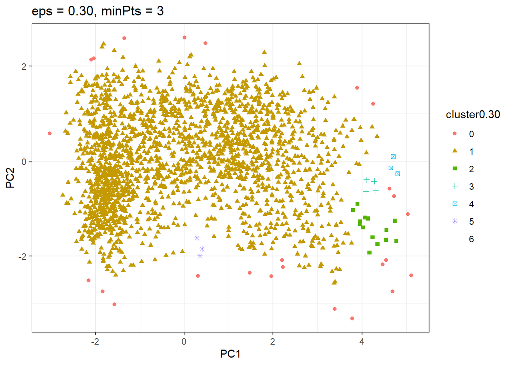

```r
ggplot(df.principal_components, aes(PC1, PC2, shape = cluster0.30, color=cluster0.30)) +
  ggtitle("eps = 0.30, minPts = 3") +
  geom_point()  +
  theme_bw()
```

[figure not shown]

```r
ggplot(df.principal_components, aes(PC1, PC2, shape = cluster0.33, color=cluster0.33)) +
  ggtitle("eps = 0.33, minPts = 3") +
  geom_point()  +
  theme_bw()
```

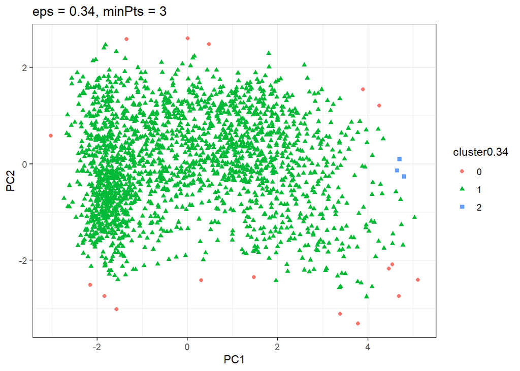

```r
ggplot(df.principal_components, aes(PC1, PC2, shape = cluster0.34, color=cluster0.34)) +
  ggtitle("eps = 0.34, minPts = 3") +
  geom_point()  +
  theme_bw()
```

## 7.2 Optimización de épsilon

Para calcular el valor óptimo de épsilon, se va a utilizar el coeficiente de silhouette.

```r
res = optics(df.principal_components[,1:2], minPts = 3)
d <- daisy(df.principal_components[,1:2])

results = seq(1:8)
i = 1
for(e in seq(0.3, 0.37, 0.01)){
  res         <- extractDBSCAN(res, eps_cl = e)
  sk          <- silhouette(res$cluster, d)
  results[i]  <- mean(sk[,3])
  i           <- i+1
}
eps_opt <- results[which.max(results)] # eps_cl óptimo
eps_opt
```

```
## [1] 0.3949606
```

```r
fit.eps_opt <- dbscan(df.principal_components[,1:2], eps = eps_opt, minPts = 3)
fit.eps_opt
```

```
## DBSCAN clustering for 2208 objects.
## Parameters: eps = 0.394960626183363, minPts = 3
## The clustering contains 1 cluster(s) and 11 noise points.
##
##    0    1
##   11 2197
##
## Available fields: cluster, eps, minPts
```

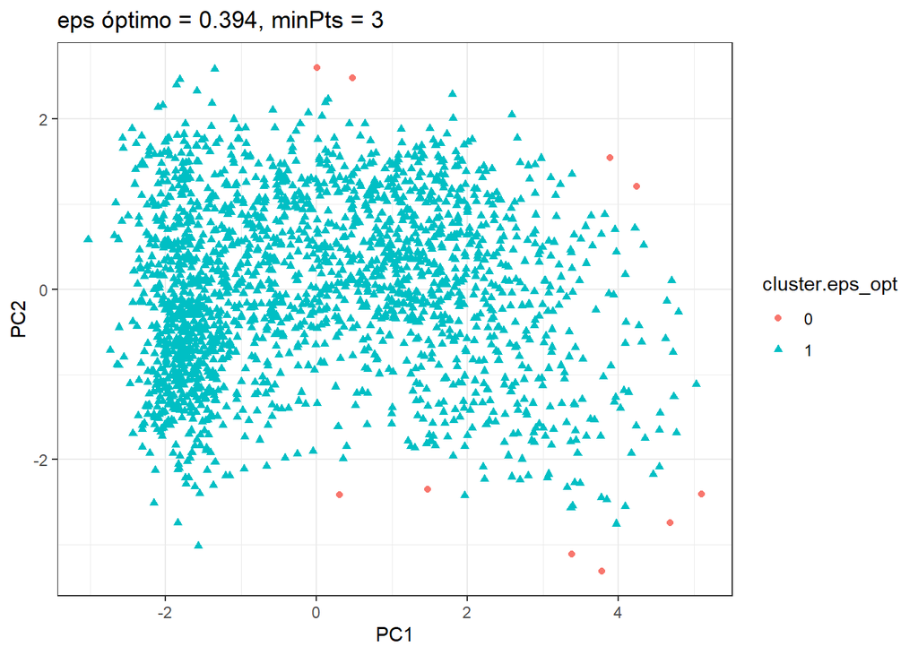

```r
df.principal_components$cluster.eps_opt <- as.factor(fit.eps_opt$cluster)

ggplot(df.principal_components, aes(PC1, PC2, shape = cluster.eps_opt, color=cluster.eps_opt)) +
  ggtitle("eps óptimo = 0.394, minPts = 3") +
  geom_point()  +
  theme_bw()
```

## 7.3 Comparación visual entre K-means y DBSCAN

A continuación, se muestran las gráficas de la clasificación real, datos agrupados utilizando K-means y DBSCAN.

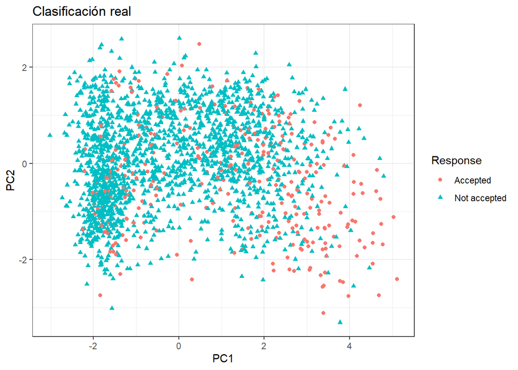

```r
ggplot(df.principal_components, aes(PC1, PC2, shape = Response, color=Response)) +
  ggtitle("Clasificación real") +
  geom_point()  +
  theme_bw()
```

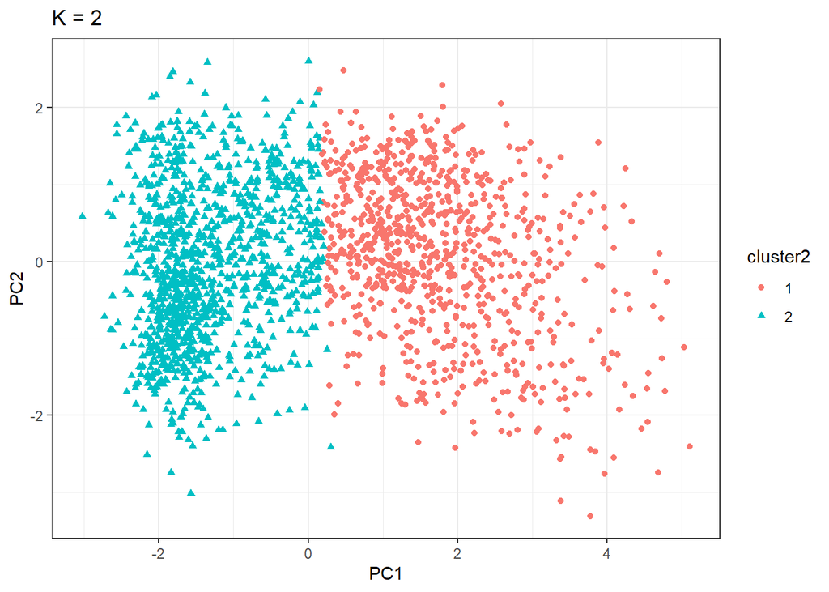

```r
ggplot(df.principal_components, aes(PC1, PC2, shape = cluster2, color=cluster2)) +
  ggtitle("K = 2") +
  geom_point()  +
  theme_bw()
```

[figure not shown]

```r
ggplot(df.principal_components, aes(PC1, PC2, shape = cluster0.33, color=cluster0.33)) +
  ggtitle("eps = 0.33, minPts = 3") +
  geom_point()  +
  theme_bw()
```

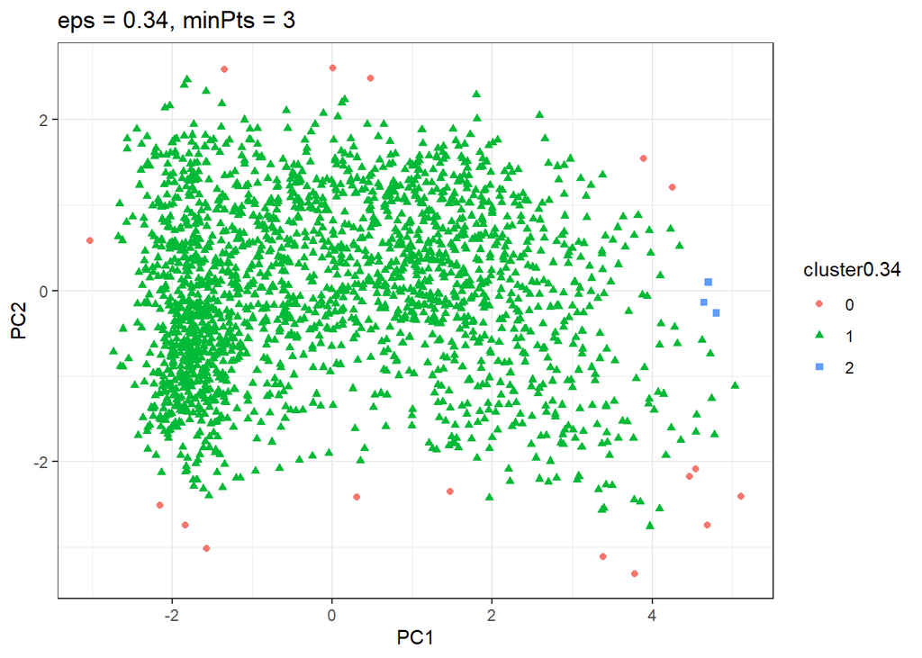

```r
ggplot(df.principal_components, aes(PC1, PC2, shape = cluster0.34, color=cluster0.34)) +
  ggtitle("eps = 0.34, minPts = 3") +
  geom_point()  +
  theme_bw()
```

Se observa en las gráficas que K-mean realiza una agrupación circular, mientras que DBSCAN agrupa los datos por regiones de alta densidad. Sin embargo, los registros “Accepted” y los “No Accepted” se están superponiendo entre ellos, lo que dificultad que un algoritmo de agrupación no supervisado clasifique de forma correctamente los registros.

## 7.4 Conclusiones

- DBSCAN define los clústeres en regiones continuas de alta densidad y no agrupa los datos de forma esférica o circular como K-means.
- El algoritmo DBSCAN fue sensible con los valores de épsilon. Por ejemplo, un valor menor a 0.3 se obtuvieron entre 60 y 200 clúster, y un valor mayor a 0.37 solo se obtuvo 1 clúster.
- Se observa en las gráficas que K-mean realiza una agrupación circular, mientras que DBSCAN agrupa los datos por regiones de alta densidad. Sin embargo, los registros “Accepted” y los “No Accepted” se están superponiendo entre ellos, lo que dificultad que un algoritmo de agrupación no supervisado clasifique de forma correctamente los registros.

# 8 Ejercicio 4

En este ejercicio se evaluará el modelo árbol de decisiones con PCA y sin PCA. El dataset se dividirá en un conjunto de entrenamiento y un conjunto de prueba. El conjunto de entrenamiento contendrá el 80% de los datos, y el 20% restantes serán de prueba.

Para dividir el dataset se utilizará la función `sample.split` del paquete `caTools`.

```r
if(!require(caTools)){
    install.packages('caTools')
  library(caTools)
}
```

También, se utilizará el paquete `C50` para el modelo árbol de decisiones.

```r
if(!require(C50)){
    install.packages('C50', repos='http://cran.us.r-project.org')
    library(C50)
}
```

## 8.1 Árbol de Desiciones con Componentes Principales

En esta sección se eligió el dataset con los tres primeros componentes principales (PC1, PC2, PC3) que representan el 83% de la variabilidad de los datos. Se toma el 80% de los datos como conjunto de entrenamiento, y el 20% restante como conjunto de prueba:

```r
set.seed(123)
split <- sample.split(df.principal_components$Response, SplitRatio = 0.80)
# Dataset de entrenamiento
training_set_pc <- subset(df.principal_components[, 1:4], split == TRUE)
# Dataset de prueba
test_set_pc <- subset(df.principal_components[, 1:4], split == FALSE)

# Se separan los datos de entrenamiento sin la variable clasificadora
trainX_pc <- training_set_pc[,1:3]
# Se separa la variable clasificadora para el entrenamiento
trainy_pc <- training_set_pc[,c('Response')]

# Se separan los datos de prueba sin la variable clasificadora
testX_pc <- test_set_pc[, 1:3]
# Se separa la variable clasificadora para la prueba
testy_pc <- test_set_pc[,c('Response')]

trainy_pc = as.factor(trainy_pc)
testy_pc = as.factor(testy_pc)

list('entrenamiento'=nrow(training_set_pc), "prueba"=nrow(test_set_pc))
```

```
## $entrenamiento
## [1] 1767
##
## $prueba
## [1] 441
```

Se visualiza que de los 2208 registros del dataset, se tomaron 1767 registros aleatorios para el entrenamiento y 441 registros aleatorias para la prueba.

### 8.1.1 Creación del modelo, calidad del modelo y extracción de reglas

Se crea el árbol de decisión utilizando los datos de entrenamiento.

```r
model_1 <- C50::C5.0(trainX_pc, trainy_pc, rules=TRUE)
summary(model_1)
```

```
##
## Call:
## C5.0.default(x = trainX_pc, y = trainy_pc, rules = TRUE)
##
##
## C5.0 [Release 2.07 GPL Edition]      Sat Jan 15 11:57:20 2022
## -------------------------------
##
## Class specified by attribute `outcome'
##
## Read 1767 cases (4 attributes) from undefined.data
##
## Rules:
##
## Rule 1: (96/30, lift 4.6)
##  PC1 > 2.200791
##  PC3 > 0.6347864
##  ->  class Accepted  [0.684]
##
## Rule 2: (1473/148, lift 1.1)
##  PC3 <= 0.6347864
##  ->  class Not accepted  [0.899]
##
## Rule 3: (1540/160, lift 1.1)
##  PC1 <= 2.200791
##  ->  class Not accepted  [0.896]
##
## Default class: Not accepted
##
##
## Evaluation on training data (1767 cases):
##
##          Rules
##    ----------------
##      No      Errors
##
##       3  229(13.0%)   <<
##
##
##     (a)   (b)    <-classified as
##    ----  ----
##      66   199    (a): class Accepted
##      30  1472    (b): class Not accepted
##
##
##  Attribute usage:
##
##   92.59% PC1
##   88.79% PC3
##
##
## Time: 0.0 secs
```

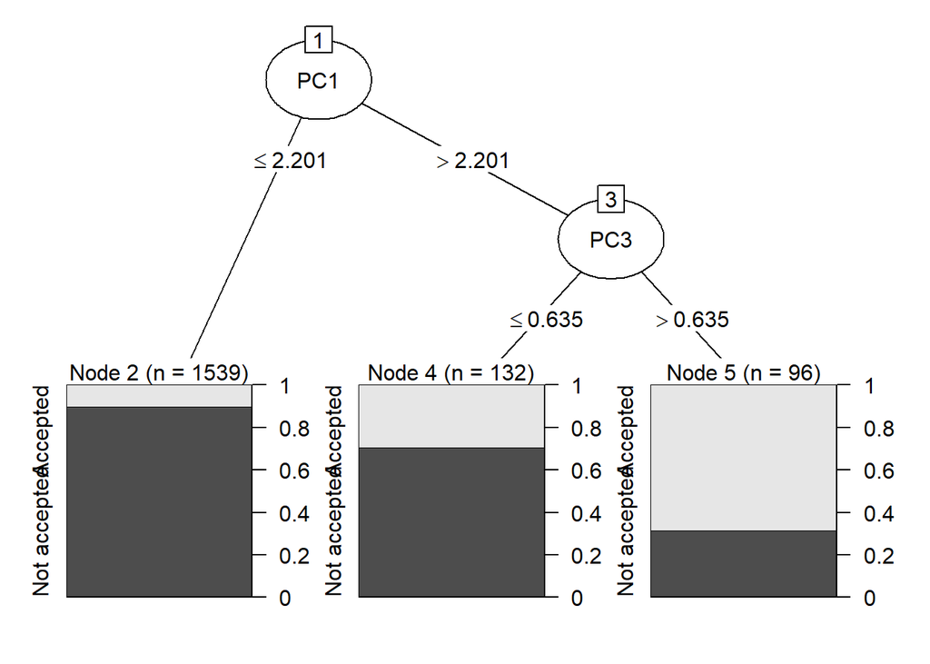

```r
model2 <- C50::C5.0(trainX_pc, trainy_pc)
plot(model2)
```

En `Errors` se muestra el número y porcentaje de casos mal clasificados en el subconjunto de entrenamiento. El árbol de decisiones clasificó erróneamente 229 de los 1767 casos dados, con una tasa de error del 13.0%.

Para que un cliente acepte la última oferta de campaña con un 68.4%, PC1 y PC3 tienen que ser mayor a 2.20079 y 0.6347864 respectivamente. El modelo C5.0 no ha considerado PC2 para clasificar los registros. El atributo que más contribuye a PC2 es la edad.

De las reglas extraídas por el algoritmo C5.0, el atributo más útil o el que permite separar mejor los datos, es el componente principal “PC1.” Los atributos que más contribuyen al PC1 son los campos `NumPurchases`, `MntSpent` e `Income`.

### 8.1.2 Análisis de la bondad de ajuste sobre el conjunto de test y matriz de confusión

Una vez que se ha entrenado el modelo, se prueba la calidad de la predicción con los datos de prueba.

```r
predicted_model <- predict(model2, testX_pc, type="class")
precision_c50 <- 100*sum(predicted_model == testy_pc) / length(predicted_model)
print(sprintf("La precisión del árbol es: %.4f %%",precision_c50))
```

```
## [1] "La precisión del árbol es: 86.8481 %"
```

La presición del modelo C5.0 es del 86.84%.

Cuando hay pocas clases, la calidad de la predicción se puede analizar mediante una matriz de confusión que identifica los tipos de errores cometidos.

```r
if(!require(gmodels)){
    install.packages('gmodels', repos='http://cran.us.r-project.org')
    library(gmodels)
}
CrossTable(testy_pc, predicted_model,prop.chisq  = FALSE, prop.c = FALSE, prop.r =FALSE,dnn = c('Reality', 'Prediction'))
```

```
##
##
##    Cell Contents
## |-------------------------|
## |                       N |
## |         N / Table Total |
## |-------------------------|
##
##
## Total Observations in Table:  441
##
##
##              | Prediction
##      Reality |     Accepted | Not accepted |    Row Total |
## -------------|--------------|--------------|--------------|
##     Accepted |           13 |           53 |           66 |
##              |        0.029 |        0.120 |              |
## -------------|--------------|--------------|--------------|
## Not accepted |            5 |          370 |          375 |
##              |        0.011 |        0.839 |              |
## -------------|--------------|--------------|--------------|
## Column Total |           18 |          423 |          441 |
## -------------|--------------|--------------|--------------|
##
##
```

Otra forma de obtener la precisión del modelo es, sumar los verdaderos positivos con los verdaderos negativos y dividirlos para el número total de registros, como se muestra a continuación:

$$precisión = \frac{Verdaderos~Positivos + Verdadero~Negativo}{Total~Registros} = 0.8684$$

### 8.1.3 Con boosting

Generamos modelo con técnica de boosting con 10 iteraciones.

```r
model3 <- C50::C5.0(trainX_pc , trainy_pc, trials=10)
summary(model3)
```

```
##
## Call:
## C5.0.default(x = trainX_pc, y = trainy_pc, trials = 10)
##
##
## C5.0 [Release 2.07 GPL Edition]      Sat Jan 15 11:57:20 2022
## -------------------------------
##
## Class specified by attribute `outcome'
##
## Read 1767 cases (4 attributes) from undefined.data
##
## -----  Trial 0:  -----
##
## Decision tree:
##
## PC1 <= 2.200791: Not accepted (1540/160)
## PC1 > 2.200791:
## :...PC3 <= 0.6347864: Not accepted (131/39)
##     PC3 > 0.6347864: Accepted (96/30)
##
## -----  Trial 1:  -----
##
## Decision tree:
##  Not accepted (1767/535.3)
##
## *** boosting reduced to 1 trial since last classifier is very inaccurate
##
## *** boosting abandoned (too few classifiers)
##
##
## Evaluation on training data (1767 cases):
##
##      Decision Tree
##    ----------------
##    Size      Errors
##
##       3  229(13.0%)   <<
##
##
##     (a)   (b)    <-classified as
##    ----  ----
##      66   199    (a): class Accepted
##      30  1472    (b): class Not accepted
##
##
##  Attribute usage:
##
##  100.00% PC1
##   12.85% PC3
##
##
## Time: 0.0 secs
```

Revisamos la precisión del modelo:

```r
predicted_model <- predict(model3, testX_pc, type="class" )
precision_c50 <- 100*sum(predicted_model == testy_pc) / length(predicted_model)
print(sprintf("La precisión del árbol es: %.4f %%",precision_c50))
```

```
## [1] "La precisión del árbol es: 86.8481 %"
```

La tasa de error con booting de 10 iteraciones es del 13%, y la precisión del modelo es del 86.84%.

Generamos modelo C5.0 con boosting de 100 iteraciones.

```r
model3 <- C50::C5.0(trainX_pc , trainy_pc, trials=100)
summary(model3)
```

```
##
## Call:
## C5.0.default(x = trainX_pc, y = trainy_pc, trials = 100)
##
##
## C5.0 [Release 2.07 GPL Edition]      Sat Jan 15 11:57:20 2022
## -------------------------------
##
## Class specified by attribute `outcome'
##
## Read 1767 cases (4 attributes) from undefined.data
##
## -----  Trial 0:  -----
##
## Decision tree:
##
## PC1 <= 2.200791: Not accepted (1540/160)
## PC1 > 2.200791:
## :...PC3 <= 0.6347864: Not accepted (131/39)
##     PC3 > 0.6347864: Accepted (96/30)
##
## -----  Trial 1:  -----
##
## Decision tree:
##  Not accepted (1767/535.3)
##
## *** boosting reduced to 1 trial since last classifier is very inaccurate
##
## *** boosting abandoned (too few classifiers)
##
##
## Evaluation on training data (1767 cases):
##
##      Decision Tree
##    ----------------
##    Size      Errors
##
##       3  229(13.0%)   <<
##
##
##     (a)   (b)    <-classified as
##    ----  ----
##      66   199    (a): class Accepted
##      30  1472    (b): class Not accepted
##
##
##  Attribute usage:
##
##  100.00% PC1
##   12.85% PC3
##
##
## Time: 0.0 secs
```

Revisamos la precisión del modelo:

```r
predicted_model <- predict(model3, testX_pc, type="class" )
precision_c50 <- 100*sum(predicted_model == testy_pc) / length(predicted_model)
print(sprintf("La precisión del árbol es: %.4f %%",precision_c50))
```

```
## [1] "La precisión del árbol es: 86.8481 %"
```

La tasa de error con booting 100 iteraciones es del 13%, y la precisión es del 86.84%.

### 8.1.4 Sin Poda

```r
model3 <- C50::C5.0(trainX_pc , trainy_pc, control=C5.0Control(noGlobalPruning=TRUE))
summary(model3)
```

```
##
## Call:
## C5.0.default(x = trainX_pc, y = trainy_pc, control
##  = C5.0Control(noGlobalPruning = TRUE))
##
##
## C5.0 [Release 2.07 GPL Edition]      Sat Jan 15 11:57:20 2022
## -------------------------------
##
## Class specified by attribute `outcome'
##
## Read 1767 cases (4 attributes) from undefined.data
##
## Decision tree:
##
## PC1 > 2.200791:
## :...PC3 <= 0.6347864: Not accepted (131/39)
## :   PC3 > 0.6347864: Accepted (96/30)
## PC1 <= 2.200791:
## :...PC3 <= 0.7660272: Not accepted (1380/112)
##     PC3 > 0.7660272:
##     :...PC2 > -1.41712: Not accepted (147/38)
##         PC2 <= -1.41712:
##         :...PC2 > -1.978451: Accepted (8)
##             PC2 <= -1.978451:
##             :...PC1 <= -1.533372: Not accepted (2)
##                 PC1 > -1.533372: Accepted (3/1)
##
##
## Evaluation on training data (1767 cases):
##
##      Decision Tree
##    ----------------
##    Size      Errors
##
##       7  220(12.5%)   <<
##
##
##     (a)   (b)    <-classified as
##    ----  ----
##      76   189    (a): class Accepted
##      31  1471    (b): class Not accepted
##
##
##  Attribute usage:
##
##  100.00% PC1
##  100.00% PC3
##    9.05% PC2
##
##
## Time: 0.0 secs
```

Revisamos la precisión del modelo:

```r
predicted_model <- predict(model3, testX_pc, type="class")
precision_c50 <- 100*sum(predicted_model == testy_pc) / length(predicted_model)
print(sprintf("La precisión del árbol es: %.4f %%",precision_c50))
```

```
## [1] "La precisión del árbol es: 86.3946 %"
```

## 8.2 Árbol de Desiciones sin Componentes Principales

En esta sección se eligirá el dataset original (sin componentes principales). Se escogerá el 80% de los datos como conjunto de entrenamiento, y el 20% restante como conjunto de prueba:

```r
# Se establace la variable clasificadora en el dataset
df.mfa$Response = df$Response

set.seed(123)
# Dataset de entrenamiento
training_set <- subset(df.mfa, split == TRUE)
# Dataset de prueba
test_set <- subset(df.mfa, split == FALSE)

# Se separan los datos de entrenamiento sin la variable clasificadora
trainX <- training_set[,"Response"!= names(df.mfa)]
# Se separa la variable clasificadora para el entrenamiento
trainy <- training_set[,c('Response')]

# Se separan los datos de prueba sin la variable clasificadora
testX<- test_set[,"Response"!= names(df.mfa)]
# Se separa la variable clasificadora para la prueba
testy<- test_set[,c('Response')]

trainy = as.factor(trainy)
testy = as.factor(testy)
```

### 8.2.1 Creación del modelo, calidad del modelo y extracción de reglas

Se crea el árbol de decisión utilizando los datos de entrenamiento.

```r
model <- C50::C5.0(trainX , trainy, rules=TRUE)
summary(model)
```

```
##
## Call:
## C5.0.default(x = trainX, y = trainy, rules = TRUE)
##
##
## C5.0 [Release 2.07 GPL Edition]      Sat Jan 15 11:57:21 2022
## -------------------------------
##
## Class specified by attribute `outcome'
##
## Read 1767 cases (10 attributes) from undefined.data
##
## Rules:
##
## Rule 1: (47/8, lift 5.4)
##  AcceptedPrv > 2
##  ->  class Accepted  [0.816]
##
## Rule 2: (28/5, lift 5.3)
##  Rel_Status = Single
##  Income > 85485
##  NumPurchases > 15
##  ->  class Accepted  [0.800]
##
## Rule 3: (135/57, lift 3.8)
##  Rel_Status = Single
##  AcceptedPrv > 0
##  ->  class Accepted  [0.577]
##
## Rule 4: (1372/105, lift 1.1)
##  Income <= 85485
##  AcceptedPrv <= 0
##  ->  class Not accepted  [0.923]
##
## Rule 5: (1110/100, lift 1.1)
##  Rel_Status = Coupled
##  AcceptedPrv <= 2
##  ->  class Not accepted  [0.909]
##
## Rule 6: (363/37, lift 1.1)
```

[output cut: 19 more lines]

```
##     104   161    (a): class Accepted
##      48  1454    (b): class Not accepted
##
##
##  Attribute usage:
##
##   99.49% AcceptedPrv
##   79.23% Income
##   70.97% Rel_Status
##   20.54% Education
##   20.54% Age
##    1.58% NumPurchases
##
##
## Time: 0.0 secs
```

En `Errors` se muestra el número y porcentaje de casos mal clasificados en el subconjunto de entrenamiento. El árbol de decisiones obtenido clasifica erróneamente 209 de los 1767 casos dados, con una tasa de error del 11.8%. Se visualizan las reglas extraídas por el algoritmo C5. El atributo más útil o el que permite separar mejor los datos, es `AcceptedPrv`.

De las reglas más importantes tenemos que si un cliente ha aceptado más de dos ofertas en el pasado, tiene una probabilidad del 81.6% de aceptar otra campaña. También, si su estado civil es soltero, tiene un salario mayor a 85,485 y ha comprado más de 15 veces en la tienda, tiene una probabilidad del 80% de aceptar otra oferta de campaña.

### 8.2.2 Análisis de la bondad de ajuste sobre el conjunto de test

Una vez que se ha entrenado el modelo, se prueba la calidad de la predicción con los datos de prueba.

```r
predicted_model <- predict(model, testX, type="class" )
precision_c50 <- 100*sum(predicted_model == testy) / length(predicted_model)
print(sprintf("La precisión del árbol es: %.4f %%",precision_c50))
```

```
## [1] "La precisión del árbol es: 85.2608 %"
```

La presición del modelo es de 85.26%.

### 8.2.3 Con boosting

Generamos modelo con técnica de boosting con 10 iteraciones

```r
model3 <- C50::C5.0(trainX , trainy, trials=10, rules=TRUE)
summary(model3)
```

```
##
## Call:
## C5.0.default(x = trainX, y = trainy, trials = 10, rules = TRUE)
##
##
## C5.0 [Release 2.07 GPL Edition]      Sat Jan 15 11:57:21 2022
## -------------------------------
##
## Class specified by attribute `outcome'
##
## Read 1767 cases (10 attributes) from undefined.data
##
## -----  Trial 0:  -----
##
## Rules:
##
## Rule 0/1: (47/8, lift 5.4)
##  AcceptedPrv > 2
##  ->  class Accepted  [0.816]
##
## Rule 0/2: (28/5, lift 5.3)
##  Rel_Status = Single
##  Income > 85485
##  NumPurchases > 15
##  ->  class Accepted  [0.800]
##
## Rule 0/3: (135/57, lift 3.8)
##  Rel_Status = Single
##  AcceptedPrv > 0
##  ->  class Accepted  [0.577]
##
## Rule 0/4: (1372/105, lift 1.1)
##  Income <= 85485
##  AcceptedPrv <= 0
##  ->  class Not accepted  [0.923]
##
## Rule 0/5: (1110/100, lift 1.1)
##  Rel_Status = Coupled
##  AcceptedPrv <= 2
##  ->  class Not accepted  [0.909]
```

[output cut: 442 more lines]

```
##
##
##  Attribute usage:
##
##  100.00% AcceptedPrv
##  100.00% MntSpent
##   99.60% Income
##   97.91% Age
##   87.27% Rel_Status
##   86.25% Education
##   84.44% MinorsHome
##   52.74% NumPurchases
##
##
## Time: 0.0 secs
```

Revisamos la precisión del modelo:

```r
predicted_model <- predict(model3, testX, type="class" )
precision_c50 <- 100*sum(predicted_model == testy) / length(predicted_model)
print(sprintf("La precisión del árbol es: %.4f %%",precision_c50))
```

```
## [1] "La precisión del árbol es: 86.1678 %"
```

Generamos modelo con técnica de boosting con 100 iteraciones.

```r
model3 <- C50::C5.0(trainX , trainy, trials=100, rules=TRUE)
summary(model3)
```

```
##
## Call:
## C5.0.default(x = trainX, y = trainy, trials = 100, rules = TRUE)
##
##
## C5.0 [Release 2.07 GPL Edition]      Sat Jan 15 11:57:21 2022
## -------------------------------
##
## Class specified by attribute `outcome'
##
## Read 1767 cases (10 attributes) from undefined.data
##
## -----  Trial 0:  -----
##
## Rules:
##
## Rule 0/1: (47/8, lift 5.4)
##  AcceptedPrv > 2
##  ->  class Accepted  [0.816]
##
## Rule 0/2: (28/5, lift 5.3)
##  Rel_Status = Single
##  Income > 85485
##  NumPurchases > 15
##  ->  class Accepted  [0.800]
##
## Rule 0/3: (135/57, lift 3.8)
##  Rel_Status = Single
##  AcceptedPrv > 0
##  ->  class Accepted  [0.577]
##
## Rule 0/4: (1372/105, lift 1.1)
##  Income <= 85485
##  AcceptedPrv <= 0
##  ->  class Not accepted  [0.923]
##
## Rule 0/5: (1110/100, lift 1.1)
##  Rel_Status = Coupled
##  AcceptedPrv <= 2
##  ->  class Not accepted  [0.909]
```

[output cut: 620 more lines]

```
##
##
##  Attribute usage:
##
##  100.00% Education
##  100.00% Rel_Status
##  100.00% AcceptedPrv
##  100.00% MntSpent
##   98.98% Income
##   98.81% Age
##   98.70% MinorsHome
##   94.11% NumPurchases
##
##
## Time: 0.1 secs
```

Revisamos la precisión del modelo:

```r
predicted_model <- predict(model3, testX, type="class" )
precision_c50 <- 100*sum(predicted_model == testy) / length(predicted_model)
print(sprintf("La precisión del árbol es: %.4f %%",precision_c50))
```

```
## [1] "La precisión del árbol es: 86.3946 %"
```

### 8.2.4 Sin Poda

```r
model3 <- C50::C5.0(trainX , trainy, control=C5.0Control(noGlobalPruning=TRUE), rules=TRUE)
summary(model3)
```

```
##
## Call:
## C5.0.default(x = trainX, y = trainy, rules = TRUE, control
##  = C5.0Control(noGlobalPruning = TRUE))
##
##
## C5.0 [Release 2.07 GPL Edition]      Sat Jan 15 11:57:21 2022
## -------------------------------
##
## Class specified by attribute `outcome'
##
## Read 1767 cases (10 attributes) from undefined.data
##
## Rules:
##
## Rule 1: (10, lift 6.1)
##  Education = Graduation
##  Age <= 45
##  Income <= 31163
##  AcceptedPrv > 0
##  ->  class Accepted  [0.917]
##
## Rule 2: (47/8, lift 5.4)
##  AcceptedPrv > 2
##  ->  class Accepted  [0.816]
##
## Rule 3: (28/5, lift 5.3)
##  Rel_Status = Single
##  Income > 85485
##  NumPurchases > 15
##  ->  class Accepted  [0.800]
##
## Rule 4: (135/57, lift 3.8)
##  Rel_Status = Single
##  AcceptedPrv > 0
##  ->  class Accepted  [0.577]
##
## Rule 5: (1372/105, lift 1.1)
##  Income <= 85485
##  AcceptedPrv <= 0
```

[output cut: 40 more lines]

```
##     100   165    (a): class Accepted
##      32  1470    (b): class Not accepted
##
##
##  Attribute usage:
##
##   99.49% AcceptedPrv
##   82.12% Income
##   70.97% Rel_Status
##   46.41% Education
##   37.97% Age
##    1.58% NumPurchases
##
##
## Time: 0.0 secs
```

Revisamos la precisión del modelo:

```r
predicted_model <- predict(model3, testX, type="class" )
precision_c50 <- 100*sum(predicted_model == testy) / length(predicted_model)
print(sprintf("La precisión del árbol es: %.4f %%",precision_c50))
```

```
## [1] "La precisión del árbol es: 85.4875 %"
```

# 9 Ejercicio 5

## 9.1 Modelo Logistic Regression con PC

En esta sección se eligió el dataset con los tres primeros componentes principales (PC1, PC2, PC3) que representan el 83% de la variabilidad de los datos. Se toma el 80% de los datos como conjunto de entrenamiento, y el 20% restante como conjunto de prueba de la sección anterior.

A continuación, se establece el modelo:

```r
# Se establece el dataset para LG
training_set_pc_gl <- training_set_pc

# Se reemplaza Accepted por 1, caso contrario 0
training_set_pc_gl$Response <- ifelse(training_set_pc$Response == "Accepted", 1, 0)

# Se cacula el modelo
model.logist = glm(formula = Response~PC1+PC2+PC3, family = binomial(link = "logit"), data = training_set_pc_gl)
summary(model.logist)
```

```
##
## Call:
## glm(formula = Response ~ PC1 + PC2 + PC3, family = binomial(link = "logit"),
##     data = training_set_pc_gl)
##
## Deviance Residuals:
##     Min       1Q   Median       3Q      Max
## -2.5241  -0.4848  -0.4129  -0.3483   2.5316
##
## Coefficients:
##             Estimate Std. Error z value Pr(>|z|)
## (Intercept) -1.99883    0.07976 -25.060  < 2e-16 ***
## PC1          0.35605    0.04029   8.837  < 2e-16 ***
## PC2         -0.49961    0.07522  -6.642 3.10e-11 ***
## PC3          0.57862    0.07403   7.816 5.44e-15 ***
## ---
## Signif. codes:  0 '***' 0.001 '**' 0.01 '*' 0.05 '.' 0.1 ' ' 1
##
## (Dispersion parameter for binomial family taken to be 1)
##
##     Null deviance: 1493.7  on 1766  degrees of freedom
## Residual deviance: 1230.4  on 1763  degrees of freedom
## AIC: 1238.4
##
## Number of Fisher Scoring iterations: 5
```

## 9.2 Análisis del modelo

Tomando los valores resultantes del modelo Regresión Logística (RL), la ecuación para calcular la probabilidad de ser “Accepted” sería:

En los resultados obtenidos, se observa que el signo del coeficiente de PC2 es negativo, es decir; cuanto más alto sea el valor de PC2, se generará una probabilidad menor de ser “Accepted.” Adicionalmente, los valores de p-value son menores al valor de significancia de 0.05, por lo tanto, las variables elegidas (PC1, PC2, PC3) son significativas para el modelo RL

## 9.3 Análisis de la bondad de ajuste sobre el conjunto de test

Para calcular la tasa de error del modelo RL, se considera el modelo generado con los datos de entrenamiento y se predecirá con el mismo dataset de entrenamiento, cuantos registros no han sido clasificados correctamente.

A continuación, se calcula la tasa de error del modelo:

```r
trainy_pc_lg <- ifelse(trainy_pc == "Accepted", 1, 0)

predicted_model <- predict(model.logist, training_set_pc_gl, type = "response")

predict_less50 <- ifelse(predicted_model >= 0.50, 1, 0)
error <- 100 - (100*sum(predict_less50 == trainy_pc_lg) / length(predicted_model))

print(sprintf("La tasa de error del modelo es: %.4f %%",error))
```

```
## [1] "La tasa de error del modelo es: 13.1862 %"
```

La tasa de error del modelo LG fue del 13.18%. A continuación, se calcula la precisión del modelo utilizando los datos de prueba.

```r
testy_pc_lg <- ifelse(testy_pc == "Accepted", 1, 0)
predicted_model <- predict(model.logist, testX_pc, type = "response")

predict_less50 <- ifelse(predicted_model >= 0.50, 1, 0)
precision <- 100*sum(predict_less50 == testy_pc_lg) / length(predicted_model)

print(sprintf("La precisión del modelo es: %.4f %%",precision))
```

```
## [1] "La precisión del modelo es: 86.6213 %"
```

La precisión del modelo LG fue del 86.62%.

## 9.4 Comparando Regresión Logistica y Árbol de Desiciones

Previo a la comparación de los modelos LG y C5.0, recordaremos algunos puntos:

- Los datos de entrenamientos son los mismos en los dos modelos.
- En el árbol de decisiones no se considera PC2 para clasificar los registros como “Accepted.”
- En la regresión lineal, mientras más alto sea el valor PC2, resultará una probabilidad menor de ser clasificado como “Accepted.”
- La regla para calificar como “Accepted” en el árbol de decisiones fue que PC1 > 2.200791 y PC3 > 0.6347864 con una probabilidad del 68%.

Creamos un dataset con un PC1 > 2.200791, un PC3 > 0.6347864 y en el PC2 se establece un valor aleatorio.

```r
# Se suma una céntesima a PC1 = 2.20 y Pc3 = 0.63
test.data = data.frame(PC1=2.21, PC2=0.52, PC3 = 0.64)
test.data = data.frame(PC1=4.21, PC2=0.0052, PC3 = 2.64)
```

A continuación, se ejecutan los modelos para su respectivo análisis:

```r
# predicción de C5.0
result1 <- predict(model_1, test.data, type="class")
# predicción de LG
result2 <- predict(model.logist, test.data, type = "response")

# valor de la predicción de C5.0
result1
```

```
## [1] Accepted
## Levels: Accepted Not accepted
```

```r
# valor de la predicción de LG
result2
```

```
##         1
## 0.7359651
```

Para la siguiente prueba, se aumenta el valor de PC2 para su respectivo análisis:

```r
test.data = data.frame(PC1=2.21, PC2=1.52, PC3 = 0.64)

result1 <- predict(model_1, test.data, type="class")
result2 <- predict(model.logist, test.data, type = "response")

# valor de la predicción de C5.0
result1
```

```
## [1] Accepted
## Levels: Accepted Not accepted
```

```r
# valor de la predicción de LG
result2
```

```
##         1
## 0.1678345
```

Comparando los dos modelos, se determina que fue más intuitivo conocer cómo el árbol de decisiones clasifica un registro como “Accepted,” a diferencia del modelo Logistic Regression que utiliza cálculos de probabilidades para ser clasificado como “Accepted.”

A continuación, se prueban los modelos generados C5.0 y Regresión Logística con los datos completos (datos de entrenamiento y datos de prueba).

```r
result1 <- predict(model_1, df.principal_components[, 1:3], type="class")
result2 <- predict(model.logist, df.principal_components[, 1:3], type = "response")

data_pred_c5  <- sum(ifelse(result1 == "Accepted", 1 , 0))/length(result1)

predict_less50 <- ifelse(result2 >= 0.50, 1, 0)
data_pred_lg <-sum(predict_less50)/length(result1)

# Datos predichos por c5
data_pred_c5
```

```
## [1] 0.05163043
```

```r
# Datos predichos por RL
data_pred_lg
```

```
## [1] 0.05208333
```

- En el dataset completo, alrededor del 85% clientes no han aceptado la campaña final, por lo tanto, los métodos de clasificación C5.0 y Regresión Logística favorecieron naturalmente la clasificación “Not Accepted.” Exiten 15% de registros clasificados como “Accepted,” pero solo un 5% de los datos fueron clasificados como “Accepted” por ambos modelos.

## 9.5 Conclusiones

- El modelo de regresión logística calcula las probabilidades de salida en términos de las entradas y no realiza una clasificación de los datos. En su lugar, las probabilidades iguales o mayores al 50% serán clasificados como “Accepted,” caso contrario “Not Accepted.”
- En el modelo regresión logística la tasa de error fue del 13.18% y la precisión fue del 86.62%. Los valores de la tasa de error y la precisión pueden variar dependiendo de la probabilidad que se determine para clasificar los registros como “Accepted.”
- Debido a que el signo del coeficiente de PC2 es negativo en la regresión logistica, el aumento de su valor, generó una disminución de la probabilidad de ser “Accepted.”
- Comparando los dos modelos, se determina que fue más intuitivo conocer cómo el árbol de decisiones clasifica un registro como “Accepted,” a diferencia del modelo Logistic Regression que utiliza cálculos de probabilidades para ser clasificado como “Accepted.”
- El mejor modelo para clasificar los datos como “Accepted” o “Not Accepted,” fue el árbol de decisiones con Componentes Principales, con un error del 13.0% y la una precisión del 86.84%.
- En el dataset completo, alrededor del 85% clientes no han aceptado la campaña final, por lo tanto, los métodos de clasificación C5.0 y Regresión Logística favorecieron naturalmente la clasificación “Not Accepted.” Exiten 15% de registros clasificados como “Accepted,” pero solo un 5% de los datos fueron clasificados como “Accepted” por ambos modelos.

# 10 Ejercicio 6

## 10.1 Limitaciones del dataset para obtener conclusiones

Se ha demostrado en las gráficas 2D de los componentes principales regiones de alta densidad donde los registros se están superponiendo entre ellos. Esto dificultó la agrupación de los datos utilizando los algoritmos K-means y DBSCAN.

En el dataset completo, alrededor del 85% clientes no han aceptado la campaña final, por lo tanto, los métodos de clasificación C5.0 y Regresión Logística favorecerieron naturalmente la clasificación “Not Accepted.” Exiten 15% de registros clasificados como “Accepted,” pero solo un 5% de los datos fueron clasificados como “Accepted” por ambos modelos.

No existe información de la ubicación de los clientes, esto podria ser un factor que determine de forma más precisa la agrupación o clasificación de los registros.

## 10.2 Posibles riesgos del uso del modelo

El algoritmo K-means no tiene un método estándar para encontrar el número óptimo de clústers. Esto conlleva a crear clústeres innecesarios u omitir clústers que reflejen la naturaleza de los datos.

El algoritmo DBSCAN es sensible con los valores de épsilon. Por ejemplo, un valor menor a 0.3 se obtuvo entre 60 y 200 clúster, y un valor mayor a 0.37 solo se obtuvo 1 clúster.

El modelo C5.0 con diferentes conjuntos de entrenamientos obtuvo diferentes tasas de errores, su causa principal se debe a que este algoritmo tiende al overfitting. Además, existe un riesgo que discrimine atributos importantes para la clasificación de los registros. Por ejemplo, el modelo discriminó PC2.

Uno de los principales riegos de la Regresión Logística es el supuesto de linealidad entre la variable dependiente y las variables independientes. Además, su interpretación es compleja a diferencia del árbol de decusaciones.

Kassambara, Alboukadel. 2017. *Practical Guide to Principal Component Methods in r: PCA, m (CA), FAMD, MFA, HCPC, Factoextra*. Vol. 2. Sthda.